# New Method of NBA Player Classification

Daniel Wolf

March 1st, 2016

## Introduction

My goal in this project is to contribute to advancing the scope and value of basketball analytics.

The methodology below is adapted from *Basketball Analytics: Spatial Tracking* by Stephen Shea. As Stephen points out, conventional player positions (i.e. point guard, center) are not well-suited for player comparison. Players listed at the same position can have very different types. For example, consider Tony Allen vs Kyle Korver for shooting guards, or DeAndre Jordan vs Andrea Bargnani for centers.

For this reason, there is a need for a new player classification structure that can compare players more precisely and effectively by grouping them based on role and/or skill set.

## Visual Classification

Consider the chart below. The location of each player is determined by his play, as measured by a select set of metrics (shown in **blue**). Each player is “pulled” toward the metrics that best define that player. For example, versatile scorers are pulled to the top-right (see **Kevin Durant**, **Dirk Nowitzki**), 3-point specialists are pulled up (see **JJ Redick**, **Steph Curry**), playmakers are pulled to the left (see **Rajon Rondo**, **Chris Paul**), and defensive big men are pulled to the bottom-right (see **DeAndre Jordan**, **Andre Drummond**).

> **The key insight is that the closer a player is to any other player on the chart, the more similar they are based on role and skill set.**

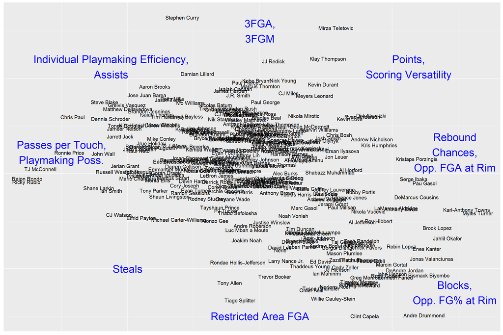

## Value Add

In this way, very precise player classifications can be defined given that players next to each other are similar. Here are three potential ways this approach could add value:

1. Support the “eye test” with data. Scouts and front offices consistently evaluate a player by referencing “similar” players to get a better understanding of how a player might fit in a system or a role.
2. Once a team need is identified, use this method to find players that fit that type and skill set. Also, if a target player has been identified, quickly identify other alternatives.
3. Taking this analysis one step further could be used to determine an optimal combination of player types to create a winning team.

## Metrics

Some of these metrics characterize a player’s role, while others describe a player’s skill within that role. The set of metrics used in this exercise can easily be adjusted depending on the intended use. All metrics were converted to **per-minute** and **normalized** in order to more effectively compare player ability while they are on the floor. Players with less than 10 GP and 15 MPG in the 2015-2016 season have been removed. There are a total of **292 players** included in this analysis.

**Opportunity Metrics: Identify the player’s ROLE (e.g. big or small)**

- 3-point Field Goals Attempted
- Restricted Area Field Goals Attempted
- Rebounding Chances
- Opponent Field Goal Attempts at Rim
- Passes per Touch
- Playmaking Possessions (how many opportunities does a player have to put other players in a position to score)

**Performance Metrics: Identify the player’s SKILL SET**

- Points
- Steals
- Assists
- Blocks
- 3-point Field Goals Made
- Opponent Field Goal Percentage at Rim
- Individual Playmaking Efficiency (how efficiently can the player put other players in a position to score)
- Scoring Versatility Index (how evenly distributed is scoring between pull-ups, close shots, drives, and catch and shoot)

All of the metrics needed for this report either come directly from NBA.com or are calculated using statistics from NBA.com.

## Focus On: Hawks

Players closest to Jeff Teague:

- Ty Lawson
- Tyreke Evans
- Mario Chalmers

Players closest to Kent Bazemore:

- Dante Cunningham
- James Johnson
- Matt Barnes

Players closest to Kyle Korver:

- PJ Hairston
- Anthony Tolliver
- Wesley Matthews

Players closest to Paul Millsap:

- Jerami Grant
- Terrence Jones
- Jared Sullinger

Players closest to Al Horford:

- Shabazz Muhammad
- Jon Leuer
- Ersan Ilyasova

Players closest to Dennis Schroder:

- Toney Douglas
- Jameer Nelson
- Steve Blake

Players closest to Thabo Sefolosha:

- PJ Tucker
- Tayshaun Prince
- Andre Roberson

Players closest to Tim Hardaway Jr.:

- Isaiah Thomas
- Manu Ginobili
- Jerryd Bayless

Players closest to Tiago Splitter:

- Tony Allen (interesting)
- Trevor Booker
- Rondae Hollis-Jefferson
- Larry Nance Jr.

Players closest to Kris Humphries:

- Andrew Nicholson
- Ersan Ilyasova
- Kristaps Porzingis

For more information or to discuss these topics in more depth, feel free to reach out to Daniel Wolf at daniel.wolf33@gmail.com. This project was completed using R programming.